# Regression

```python
import numpy
from matplotlib import pyplot as plt
%matplotlib inline
```

## Linear regression

Data from Example 6.1 of Seborg, Edgar, Melichamp and Doyle (3rd edition)

```python
import pandas
```

```python
df = pandas.read_excel('example_6_1.xlsx')
```

```python
x = df['Fuel Flow Rate']
y = df['Power Generated']
```

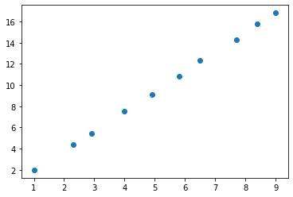

```python
plt.scatter(x, y)
```

That resembles a straight line! Let's say the line is described by

$$y = ax + b$$

In regression, we are trying to find $a$ and $b$ given lots of values for $y$ and $x$, so we have something like

\begin{align} y_0 &= ax_0 + b \\ y_1 &= ax_1 + b \\ y_2 &= ax_2 + b \\ \vdots &= \vdots \\ \end{align}

Which we factor as

$$\underbrace{\begin{bmatrix}y_0\\y_1\\\vdots \end{bmatrix}}_Y = \underbrace{\begin{bmatrix}x_0 & 1 \\x_1 & 1\\\vdots & \vdots \end{bmatrix}}_X \underbrace{\begin{bmatrix}a\\b\end{bmatrix}}_\beta$$

In this case, when there are many points, $X$ is taller than it is wide and as such we know that there is no solution to the exact equations. Instead, we may try to get "close" to the solution. We can write the residuals as

$$\epsilon = Y - X\beta$$

Here, $\epsilon$ is a vector of errors, one for each data point. The (euclidian) length of this vector is given by

$$||\epsilon|| = \sqrt{\sum_i \epsilon_i^2}$$

It is common to focus on minimising the part without the square root to make calculations simpler. This leads to the popular way of determining the error of a fit called the "sum of square errors", sometimes expressed as $||\epsilon||^2$.

This minimisation is written in mathematical notation as

$$\min_\beta \sum_i \epsilon_i^2$$

which is read in words as as "minimise (*with respect to* or *by changing* $\beta$) the sum of the square error".

## Create the design matrices

The matrices $Y$ and $X$ are sometimes called the design matrices. We can build them using basic numpy functions as follows:

```python
Y = numpy.asmatrix(y).T
X = numpy.bmat([numpy.c_[x], numpy.ones_like(Y)])
```

*Note* `numpy.c_` produces a two dimensional array from a one dimensional one in a *c*olumn.

In the case of polynomials, $X$ is a special matrix called a [Vandermonde matrix](https://en.wikipedia.org/wiki/Vandermonde_matrix), and numpy has a function which generates them more easily.

```python
X = numpy.asmatrix(numpy.vander(x, 2))
```

There is also a library called [patsy](https://patsy.readthedocs.io) which supplies a simplified syntax to construct these matrices:

```python
import patsy
```

```python
Y, X = patsy.dmatrices("Q('Power Generated') ~ Q('Fuel Flow Rate')", df)
```

```python
Y, X = map(numpy.asmatrix, (Y, X))
```

### Pseudoinverse solution

First, let's apply the pseudoinverse method directly (note **you should never do this for production code**, as calculating inverses is computationally expensive)

The solution minimising the sum of the squares of the residual $||\epsilon||^2$ can be shown to be

$$ \hat{\beta} = (X^TX)^{-1}X^T Y $$

```python
#Excel: =MMULT((MINVERSE(MMULT(TRANSPOSE(_X); _X))); MMULT(TRANSPOSE(_X); _Y))
betahat = (X.T * X).I * X.T * Y
betahat
```

```
matrix([[0.07854918],
        [1.85932397]])
```

*Note:* The code above is as close as possible to the equation above, as I have made `X` and `Y` matrices. **The numpy developers advise against using the `numpy.matrix` class**.

Matrix properties:

- `.T`: Transpose
- `.I`: Inverse
- `.A`: Array form of matrix

Normal `numpy.array`s don't have an `.I` property and don't multiply matrix-fasion but rather element-wise. Here is how we would have to write the code if we used arrays:

```python
Y = Y.A
X = X.A
```

```python
numpy.linalg.inv(X.T @ X) @ X.T @ Y
```

```
array([[0.07854918],
       [1.85932397]])
```

The `@` operator always does matrix multiplication and expects two-dimensional arrays on both sides.

### Dedicated solvers

Calculating the inverse is not a numerically well behaved operation, so you should rather use a dedicated routine if you are solving this kind of problem:

```python
beta, residuals, rank, s = numpy.linalg.lstsq(X, Y, rcond=None)
beta
```

```
array([[0.07854918],
       [1.85932397]])
```

However, polynomial fits are such a common operation that there are nicer routines to do this fit. There are a whole range of functions in numpy which start with poly. Press tab to see them.

```python
numpy.poly
```

```
<function numpy.poly(seq_of_zeros)>
```

```python
poly = numpy.polyfit(x, y, 1)
poly
```

```
array([1.85932397, 0.07854918])
```

Notice that we could just pass the data directly, and the routine handled building the various matrices and the fitting itself.

It is useful to plot the regression with the data points, but we should sample on a finer grid.

```python
smoothx = numpy.linspace(min(x), max(x), 1000)
```

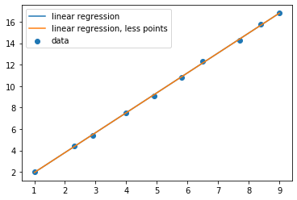

```python
def regplot(poly):
    smoothy = numpy.polyval(poly, smoothx)
    plt.scatter(x, y, label='data')
    plt.plot(smoothx, smoothy, label='linear regression')
    plt.plot(x, numpy.polyval(poly, x), label='linear regression, less points')
    plt.legend(loc='best')
regplot(poly)
```

There's obviously no difference between the two for a linear fit, but what about higher orders?

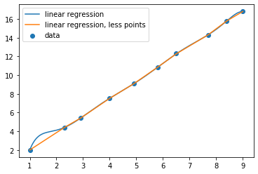

```python
poly9 = numpy.polyfit(x, y, 8)
regplot(poly9)
```

If we had just plotted the connecting lines, we would have missed the bit sticking up on the left!